# ANOVA Practice

# Life Expectancy of Female Authors

## Introduction

You are curious to compare life expectancy between female poets, novelists, and non-fiction writers.

You take a sample of female authors from each of the three groups to test if the average age at death is different between any of the three types of authors using a level of significance of, $\alpha = 0.05$.

## Load the Data and Libraries

```r
library(rio)
library(tidyverse)
library(mosaic)
library(car)
womenpoet <- rio::import("https://byuistats.github.io/BYUI_M221_Book/Data/womenpoet.xls")
glimpse(womenpoet)
```

```
Rows: 123
Columns: 2
$ Type <chr> "Novels", "Novels", "Novels", "Novels", "Novels", "Novels", "Nove…
$ Age  <dbl> 57, 90, 67, 56, 90, 72, 56, 90, 80, 74, 73, 86, 53, 72, 86, 82, 7…
```

## Explore the Data

Create a side-by-side boxplot of the age at death of each of the different author styles.

Modify the colors of each of the boxes for each group.

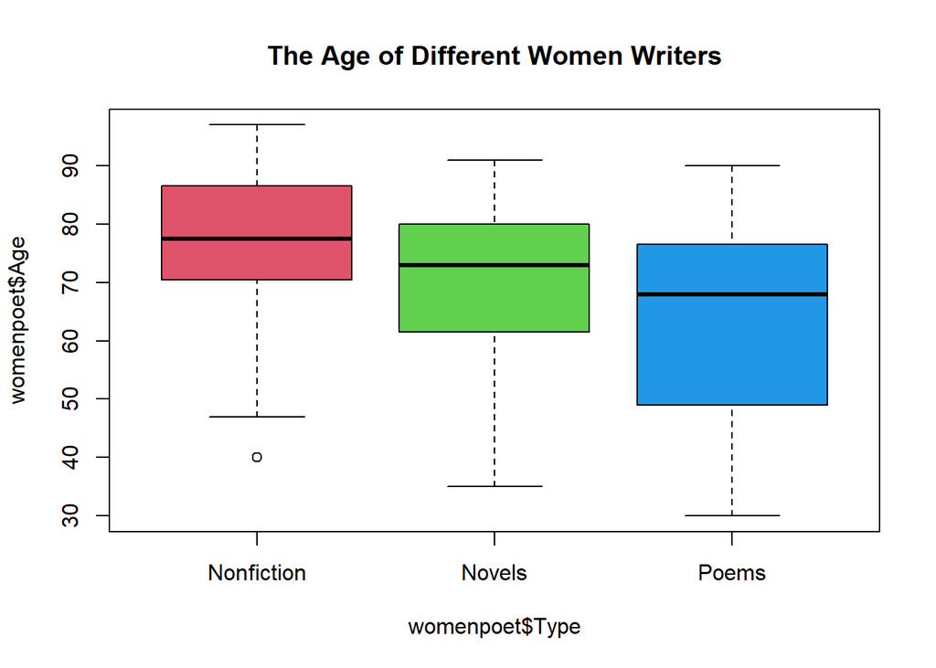

```r
boxplot(womenpoet$Age ~ womenpoet$Type, main = "The Age of Different Women Writers", col = c(2,3,4))
```

Create a summary statistics table for age at death for each author type:

```r
favstats(womenpoet$Age ~ womenpoet$Type) %>% knitr::kable()
```

| womenpoet$Type | min | Q1 | median | Q3 | max | mean | sd | n | missing |
| --- | --- | --- | --- | --- | --- | --- | --- | --- | --- |
| Nonfiction | 40 | 71.75 | 77.5 | 86.25 | 97 | 76.87500 | 14.09691 | 24 | 0 |
| Novels | 35 | 61.50 | 73.0 | 80.00 | 91 | 71.44776 | 13.05151 | 67 | 0 |
| Poems | 30 | 49.50 | 68.0 | 75.75 | 90 | 63.18750 | 17.29710 | 32 | 0 |

List the mean and standard deviations of age at death for:

| womenpoet$Type | mean | sd | n | missing |
| --- | --- | --- | --- | --- |
| Nonfiction | 76.87500 | 14.09691 | 24 | 0 |
| Novels | 71.44776 | 13.05151 | 67 | 0 |
| Poems | 63.18750 | 17.29710 | 32 | 0 |

## Perform the Appropriate Analysis

State your null and alternative hypotheses:

$$H_o = u_{Nonfiction} = u_{Novel} = u_{Poem}$$

$$H_a = At\ least\ one\ of\ the\ u\ not\ equals\ to\ another\ one.$$

Perform an Analysis of Variance test including checking for the appropriateness of our analysis.

```r
aov_women_writer <- aov(womenpoet$Age ~ womenpoet$Type)
aov_women_writer
```

```
Call:
   aov(formula = womenpoet$Age ~ womenpoet$Type)

Terms:
                womenpoet$Type Residuals
Sum of Squares        2744.193 25088.067
Deg. of Freedom              2       120

Residual standard error: 14.45916
Estimated effects may be unbalanced
```

```r
summary(aov_women_writer)
```

```
                Df Sum Sq Mean Sq F value  Pr(>F)
womenpoet$Type   2   2744  1372.1   6.563 0.00197 **
Residuals      120  25088   209.1
---
Signif. codes:  0 '***' 0.001 '**' 0.01 '*' 0.05 '.' 0.1 ' ' 1
```

**Question**: What is the test statistic (F-value)? **Answer**: 6.563

**Question**: What are the degrees of freedom for your analysis? a. Numerator (between Groups) Degrees of Freedom b. Denominator (within groups) Degrees of Freedom **Answer**: a = 2; b = 120

**Question**: What is the P-value? **Answer**: 0.00197

**Question**: Do you reject the null hypothesis? Why? **Answer**: Yes, I will reject the null hypothesis since the P-value is less than alpha-value (0.00197 < 0.05)

**Question**: State your conclusion in context of the problem. **Answer**: I have sufficient evidence to suggest that the average age among women writers in Nonficition, Novel, and Poem field are not all equal to each other.

```r
sds = favstats(womenpoet$Age ~ womenpoet$Type)$sd

max(sds) / min(sds)
```

```
[1] 1.325295
```

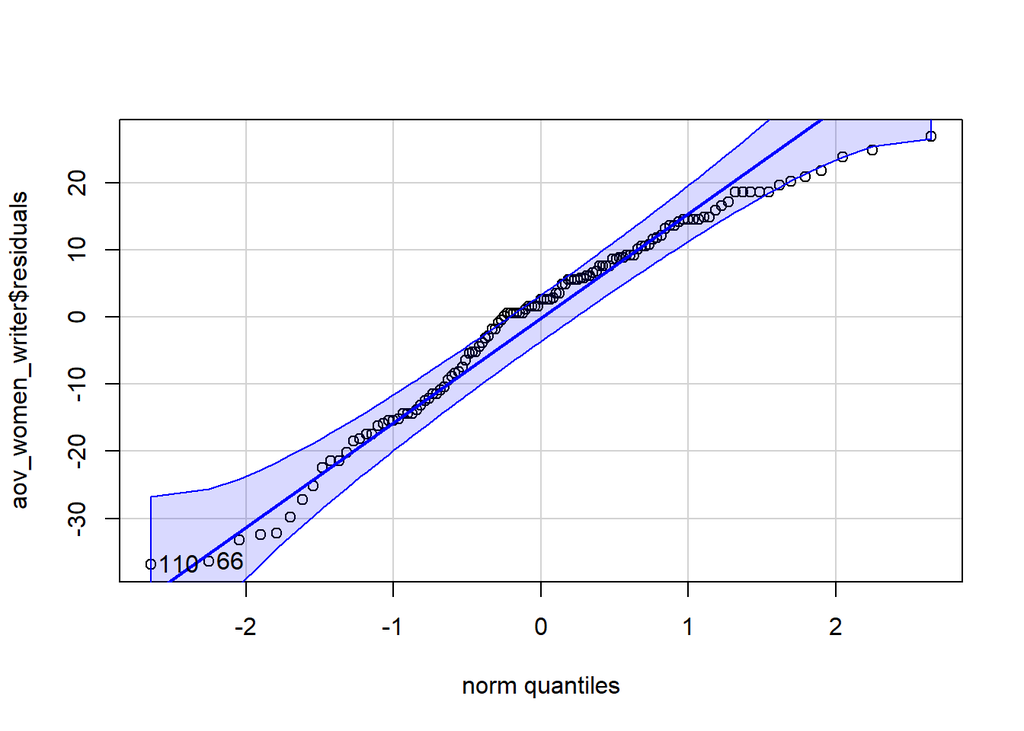

```
[1] 110  66
```

```r
qqPlot(aov_women_writer$residuals)
```

**Question**: Can we trust the p-value? a. Check for equal standard deviation (is the ratio of the largest SD / smallest SD greater than 2?) b. Check Normality of the residuals (`qqPlot()`) **Answer**: Yes. According to the result of equal standard deviation test (1.325295 < 2, test passed) and qqPlot graph (graph shows that the residuals are normal distributed), we can trust the p-value.

# Testing Mosquitos

## Introduction

A study was conducted to determine if different types of material can reduce the amount of mosquito human contact. The researchers evaluated five different types of patches 1=Odomos, 2=Deltamethrin, 3=Cyfluthrin, 4=D+O, 5=C+O.

The amount of mosquito human contact was measured to assess any differences between the five different types of material. Use a level of significance of 0.05.

## Load the Data

```r
MosquitoPatch <- rio::import("https://raw.githubusercontent.com/rdcromar/Math221D/main/MosquitoPatch.csv") %>% mutate(Treatment = factor(Treatment))

glimpse(MosquitoPatch)
```

```
Rows: 150
Columns: 2
$ Treatment <fct> 1, 1, 1, 1, 1, 1, 1, 1, 1, 1, 1, 1, 1, 1, 1, 1, 1, 1, 1, 1, …
$ mosqs     <dbl> 4.50, 10.04, 13.05, 0.26, 10.61, 10.89, 6.86, 6.97, 6.90, 5.…
```

## Review the Data

Create a side-by-side boxplot for human contact for each of the treatment groups.

Add a title and change the colors of the boxes.

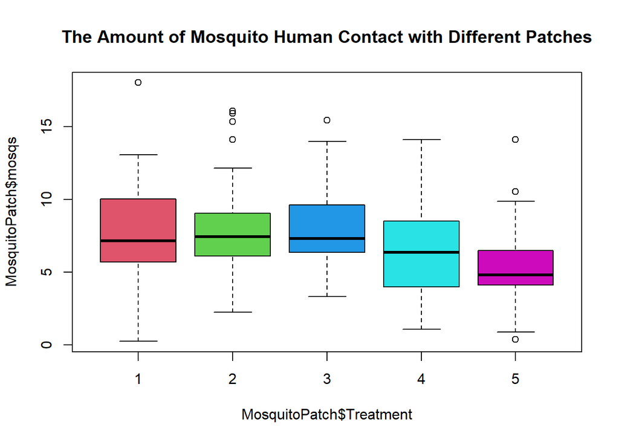

```r
boxplot(MosquitoPatch$mosqs ~ MosquitoPatch$Treatment, main = "The Amount of Mosquito Human Contact with Different Patches", col = c(2,3,4,5,6))
```

Create a summary statistics table for human contact for each of the treatment groups:

```r
favstats(MosquitoPatch$mosqs ~ MosquitoPatch$Treatment) %>% knitr::kable()
```

| MosquitoPatch$Treatment | min | Q1 | median | Q3 | max | mean | sd | n | missing |
| --- | --- | --- | --- | --- | --- | --- | --- | --- | --- |
| 1 | 0.26 | 5.7375 | 7.140 | 9.9075 | 18.01 | 7.900667 | 3.366488 | 30 | 0 |
| 2 | 2.26 | 6.1225 | 7.445 | 8.9050 | 16.07 | 8.133000 | 3.460182 | 30 | 0 |
| 3 | 3.33 | 6.3975 | 7.320 | 9.6225 | 15.44 | 8.032667 | 3.010318 | 30 | 0 |
| 4 | 1.10 | 4.0100 | 6.355 | 8.2500 | 14.10 | 6.333333 | 3.121368 | 30 | 0 |
| 5 | 0.39 | 4.1500 | 4.825 | 6.4725 | 14.10 | 5.367000 | 3.067773 | 30 | 0 |

## Perform the Appropriate Analysis

State your null and alternative hypotheses:

$$H_o = u_{Odomos} = u_{Deltamethrin} = u_{Cyfluthrin} = u_{D+O} = u_{C+O}$$

$$H_a = At\ least\ one\ of\ the\ u\ not\ equals\ to\ another\ one.$$

Perform an Analysis of Variance test including checking for the appropriateness of our analysis.

```r
aov_MosPatches <- aov(MosquitoPatch$mosqs ~ MosquitoPatch$Treatment)
aov_MosPatches
```

```
Call:
   aov(formula = MosquitoPatch$mosqs ~ MosquitoPatch$Treatment)

Terms:
                MosquitoPatch$Treatment Residuals
Sum of Squares                  184.646  1494.146
Deg. of Freedom                       4       145

Residual standard error: 3.210055
Estimated effects may be unbalanced
```

```r
summary(aov_MosPatches)
```

```
                         Df Sum Sq Mean Sq F value  Pr(>F)
MosquitoPatch$Treatment   4  184.6   46.16    4.48 0.00192 **
Residuals               145 1494.1   10.30
---
Signif. codes:  0 '***' 0.001 '**' 0.01 '*' 0.05 '.' 0.1 ' ' 1
```

**Question**: What is the test statistic (F-value)? **Answer**: 4.48

**Question**: What are the degrees of freedom for your analysis?

1. Numerator (between Groups) Degrees of Freedom
2. Denominator (within groups) Degrees of Freedom **Answer**: a = 4; b = 145

**Question**: What is the P-value? **Answer**: 0.00192

**Question**: Do you reject the null hypothesis? Why? **Answer**: Yes, since the P-value is less than alpha-value (0.00192 < 0.05)

**Question**: State your conclusion in context of the problem. **Answer**: I have sufficient evidence to suggest the average performance of reducing the amount of mosquito human contact among the 5 patches not all equal to each others.

```r
sds = favstats(MosquitoPatch$mosqs ~ MosquitoPatch$Treatment)$sd
max(sds) / min(sds)
```

```
[1] 1.149441
```

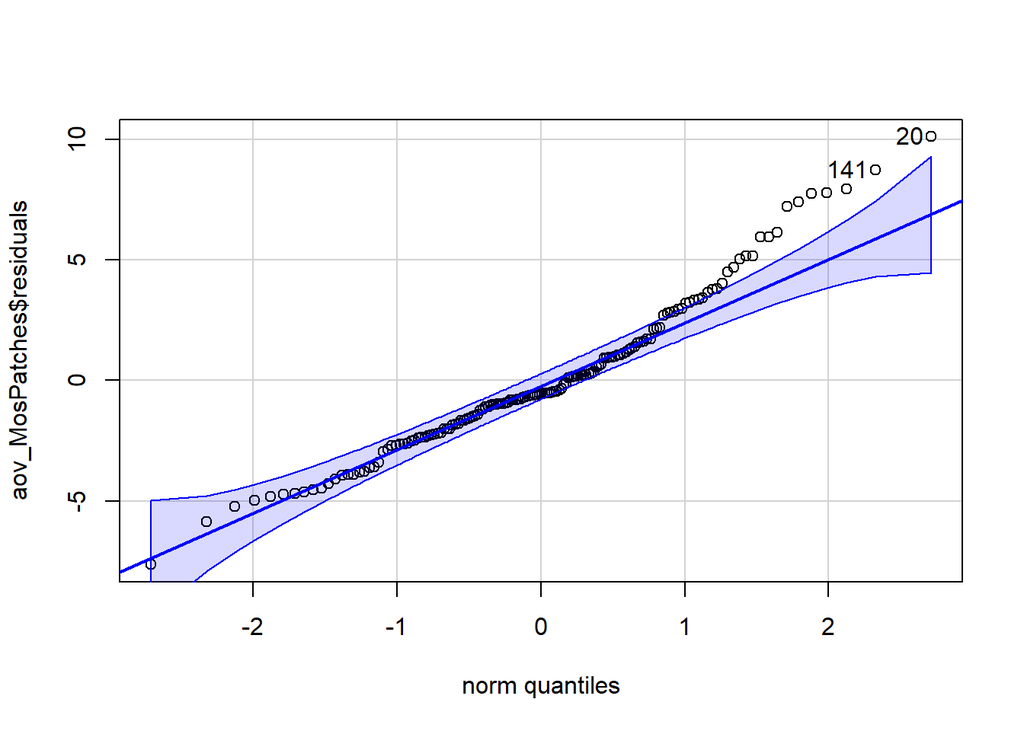

```
[1]  20 141
```

```r
qqPlot(aov_MosPatches$residuals)
```